# Mendelian Randomization Analysis: Alzheimer's Disease and Trigliceryids

By Dr. Shea Andrews, generated on 2018-09-09

```
## [1] FALSE
```

## Data sources

*Trigliceryids* [Willer et al Nat Genet 2013](https://www.nature.com/articles/ng.2797): To identify new loci and refine known loci influencing these lipids, we examined 188,577 individuals using genome-wide and custom genotyping arrays. We identify and annotate 157 loci associated with lipid levels at P < 5 × 10−8, including 62 loci not previously associated with lipid levels in humans.

*Late Onset Alzheimer’s disease* (LOAD, Lambert et al 2013): The International Genomics of Alzheimer’s Project (IGAP) is a meta-analysis of 4 previously published GWAS datasets: the European Alzheimer’s Disease Imitative (EADI), the Alzheimer Disease Genetics Consortium (ADGC), Cohorts for Heart and Aging Research in Genomic Epidemiology (CHARGE), and Genetic and Environmental Risk in AD (GERAD) and includes a sample of 17,008 LOAD cases and 37,154 cognitively normal elder controls. Participants in IGAP were of European ancestry, the average age was 71 and 58.4% of participants were women.

*Alzheimer’s Age of Onset Surivial* (AAOS, Huang et al 2017): A GWAS of age of onset in LOAD was conducted in 14,406 AD case samples and 25,849 control samples from the IGAP using Cox proportional hazard regressions. Participants were of European ancestry, in cases the the average AAO was 74.8 and 61.7% were women, in controls the average AAE was 79.0 and 59.6% were women.

*Hippocampal Volume* [Hibar et al 2017](https://doi.org/10.1038/ncomms13624): A GWAS of hippocampal volume perfomed in 26,814 (ENIGMA and CHARGE consortiums) individules of European Ancestry discovered 9 independent loci.

*CSF Ab42, tau & ptau* (AB42, ptau, tau, Deming et al 2017): A GWAS of CSF AB42, ptau and tau levels (pg/mL) was conducted in 3,146 participants. Participants were of Eurpean ancestry.

## Instrumental Vaibles

**LD Clumping:** For standard two sample MR it is important to ensure that the instruments for the exposure are independent. LD clumping can be performed using the data_clump function from the TwoSampleMR package, which uses EUR samples from the 1000 genomes project to estimate LD between SNPs and amonst SNPs that have and LD above a given threshold, only the SNP with the lowest p-value will be retained.

**Proxy SNPs:** SNPs associated with LOAD, AAOS, AB42, ptau and tau were extracted from the GWAS of Trigliceryids. Where SNPs were not available in the outcome GWAS, the EUR thousand genomes was queried to identified potential proxy SNPs that are in linkage disequilibrium (r2 > 0.8) of the missing SNP.

### LOAD

LOAD: 2213 SNPs were associated with LOAD at p < 5e-6, with 89 SNPs remaining after LD clumping (Table 1).

**Table 1:** SNPS associated with LOAD

| SNP | CHR | POS | Effect_allele | Non_Effect_allele | EAF | Beta | SE | P | r2 | N |
| --- | --- | --- | --- | --- | --- | --- | --- | --- | --- | --- |
| rs1410397 | 1 | 193627682 | C | T | 0.5348 | 0.0766 | 0.0160 | 1.616e-06 | 0.002919568 | 54162 |
| rs1752684 | 1 | 207747296 | A | G | 0.1987 | 0.1541 | 0.0196 | 3.653e-15 | 0.007561854 | 54162 |
| rs4147104 | 1 | 207882194 | A | G | NA | 0.0774 | 0.0167 | 3.421e-06 | NA | 54162 |
| rs4663105 | 2 | 127891427 | C | A | 0.5664 | 0.1837 | 0.0172 | 1.001e-26 | 0.016575278 | 54162 |
| rs745717 | 2 | 127893897 | C | G | 0.0992 | 0.2008 | 0.0288 | 2.879e-12 | 0.007206053 | 54162 |
| rs62273237 | 3 | 128310107 | T | C | 0.4035 | 0.0748 | 0.0160 | 2.768e-06 | 0.002693315 | 54162 |
| rs7657553 | 4 | 11723235 | A | G | 0.2797 | 0.0830 | 0.0172 | 1.462e-06 | 0.002775825 | 54162 |
| rs190982 | 5 | 88223420 | G | A | 0.6141 | -0.0799 | 0.0170 | 2.547e-06 | 0.003025781 | 54162 |
| rs2878896 | 5 | 139710507 | G | A | 0.5077 | 0.0833 | 0.0156 | 9.219e-08 | 0.003468622 | 54162 |
| rs28895055 | 6 | 32417185 | G | A | 0.8762 | 0.1193 | 0.0253 | 2.299e-06 | 0.003087698 | 54162 |

[output cut: 79 more lines]

Of the the 89 SNPs associated with LOAD, 28 were available in the Trigliceryids GWAS (Table 2).

**Table 2:** SNPS associated with Trigliceryids avalible in LOAD GWAS

| SNP | CHR | POS | Effect_allele | Non_Effect_allele | EAF | Beta | SE | P | r2 | N |
| --- | --- | --- | --- | --- | --- | --- | --- | --- | --- | --- |
| rs1410397 | 1 | 193627682 | T | C | 0.50660 | 0.0098 | 0.0047 | 5.938e-02 | 4.801163e-05 | 91013.00 |
| rs1752684 | 1 | 207784968 | G | A | 0.80080 | 0.0033 | 0.0058 | 5.236e-01 | 3.474332e-06 | NA |
| rs62273237 | 3 | 128316939 | T | C | 0.36810 | 0.0007 | 0.0049 | 7.199e-01 | 2.279503e-07 | NA |
| rs7657553 | 4 | 11711232 | G | A | 0.71900 | 0.0062 | 0.0051 | 1.638e-01 | 1.553276e-05 | NA |
| rs190982 | 5 | 88223420 | A | G | 0.63460 | 0.0062 | 0.0054 | 3.675e-01 | 1.782715e-05 | 91013.00 |
| rs2878896 | 5 | 139710507 | G | A | 0.49340 | 0.0019 | 0.0048 | 5.774e-01 | 1.804685e-06 | 91013.00 |
| rs28895055 | 6 | 32415858 | G | A | 0.18210 | 0.0092 | 0.0065 | 1.329e-01 | 2.521249e-05 | NA |
| rs9381563 | 6 | 47432637 | T | C | 0.66890 | 0.0049 | 0.0050 | 2.407e-01 | 1.063512e-05 | 91013.00 |
| rs59415886 | 7 | 37885121 | A | G | 0.65960 | 0.0057 | 0.0049 | 2.294e-01 | 1.458982e-05 | NA |
| rs10808026 | 7 | 143109139 | A | C | 0.22820 | 0.0067 | 0.0062 | 4.506e-01 | 1.581248e-05 | NA |

[output cut: 39 more lines]

### AAOS

AAOS: 570 SNPs were associated with AAOS at p < 5e-6, with 61 SNPs remaining after LD clumping (Table 3).

**Table 3:** SNPS associated with AAOS

| SNP | CHR | POS | Effect_allele | Non_Effect_allele | EAF | Beta | SE | P | r2 | N |
| --- | --- | --- | --- | --- | --- | --- | --- | --- | --- | --- |
| rs2649062 | 1 | 5799177 | A | G | 0.6808 | -0.0652 | 0.0131 | 6.120e-07 | 0.001847599 | 40255 |
| rs4662080 | 1 | 14363419 | T | C | 0.6649 | 0.1421 | 0.0296 | 1.586e-06 | 0.008998061 | 40255 |
| rs10919252 | 1 | 169802956 | C | G | 0.6725 | -0.0975 | 0.0198 | 8.182e-07 | 0.004187384 | 40255 |
| rs6701713 | 1 | 207786289 | A | G | 0.2017 | 0.0709 | 0.0146 | 1.184e-06 | 0.001618805 | 40255 |
| rs144505123 | 1 | 221802052 | T | C | 0.0113 | 0.7709 | 0.1609 | 1.661e-06 | 0.013279113 | 40255 |
| rs6718282 | 2 | 18039651 | A | G | 0.0440 | -0.1421 | 0.0308 | 3.840e-06 | 0.001698747 | 40255 |
| rs114131510 | 2 | 78420700 | A | G | 0.9838 | -0.6419 | 0.1406 | 4.949e-06 | 0.013133685 | 40255 |
| rs12615104 | 2 | 109820829 | T | C | 0.7434 | 0.1057 | 0.0221 | 1.829e-06 | 0.004262449 | 40255 |
| rs111906619 | 2 | 127789085 | T | C | 0.0709 | 0.1268 | 0.0256 | 7.088e-07 | 0.002118250 | 40255 |
| rs10194375 | 2 | 127839781 | A | C | 0.3494 | 0.0588 | 0.0126 | 3.342e-06 | 0.001571888 | 40255 |

[output cut: 51 more lines]

Of the the 61 SNPs associated with AAOS, 19 were available in the Trigliceryids GWAS (Table 4).

**Table 4:** SNPS associated with Trigliceryids avalible in AAOS GWAS

| SNP | CHR | POS | Effect_allele | Non_Effect_allele | EAF | Beta | SE | P | r2 | N |
| --- | --- | --- | --- | --- | --- | --- | --- | --- | --- | --- |
| rs2649062 | 1 | 5800904 | A | G | 0.68870 | 0.0051 | 0.0051 | 3.546e-01 | 1.115269e-05 | NA |
| rs10919252 | 1 | 169802956 | C | G | NA | 0.0033 | 0.0049 | 5.512e-01 | NA | 91013.00 |
| rs6701713 | 1 | 207786289 | G | A | 0.80080 | 0.0034 | 0.0058 | 5.135e-01 | 3.688088e-06 | 91013.00 |
| rs6718282 | 2 | 18039651 | A | G | 0.04749 | 0.0116 | 0.0112 | 2.196e-01 | 1.217356e-05 | 91013.00 |
| rs12615104 | 2 | 109820829 | T | C | 0.74930 | 0.0007 | 0.0052 | 9.057e-01 | 1.840925e-07 | 91013.00 |
| rs10194375 | 2 | 127839781 | A | C | 0.36940 | 0.0076 | 0.0049 | 4.805e-01 | 2.690965e-05 | 91013.00 |
| rs71602496 | 4 | 658304 | A | G | 0.84040 | 0.0017 | 0.0065 | 7.223e-01 | 7.752589e-07 | NA |
| rs1689013 | 4 | 181046865 | C | T | 0.24930 | 0.0039 | 0.0054 | 5.048e-01 | 5.693088e-06 | NA |
| rs12153819 | 6 | 83808086 | C | T | 0.84960 | 0.0063 | 0.0070 | 4.940e-01 | 1.014316e-05 | NA |
| rs17170228 | 7 | 33076314 | A | G | 0.05409 | 0.0082 | 0.0098 | 2.206e-01 | 6.880571e-06 | 87887.00 |

[output cut: 24 more lines]

### Hippocampul volume

hipv: 907 SNPs were associated with hipv at p < 5e-6, with 31 SNPs remaining after LD clumping (Table 1).

**Table 1:** SNPS associated with hipv

| SNP | CHR | POS | Effect_allele | Non_Effect_allele | EAF | Zscore | Beta | SE | P | r2 | N |
| --- | --- | --- | --- | --- | --- | --- | --- | --- | --- | --- | --- |
| rs2268894 | 2 | 162856148 | T | C | 0.5412 | -6.546 | -0.05668170 | 0.008658983 | 5.894e-11 | 0.0015955004 | 26814 |
| rs429358 | 19 | 45411941 | T | C | 0.8463 | 5.066 | 0.06342470 | 0.012519680 | 4.067e-07 | 0.0010465139 | 24498 |
| rs11979341 | 7 | 155797978 | C | G | 0.6837 | -6.755 | -0.06558167 | 0.009708611 | 1.424e-11 | 0.0018602003 | 24484 |
| rs7976802 | 12 | 65828547 | A | T | 0.3781 | 6.359 | 0.05658511 | 0.008898429 | 2.028e-10 | 0.0015057803 | 26814 |
| rs11245365 | 10 | 126482389 | A | G | 0.5648 | -5.092 | -0.04474128 | 0.008786582 | 3.547e-07 | 0.0009840798 | 26322 |
| rs61921502 | 12 | 65832468 | T | G | 0.8466 | 9.017 | 0.10788399 | 0.011964511 | 1.941e-19 | 0.0030230661 | 26814 |
| rs17177768 | 12 | 65552794 | T | C | 0.2504 | -7.702 | -0.07668244 | 0.009956172 | 1.339e-14 | 0.0022074237 | 26814 |
| rs77956314 | 12 | 117323367 | T | C | 0.9160 | -10.418 | -0.16185421 | 0.015536016 | 2.055e-25 | 0.0040313709 | 26814 |
| rs2641539 | 12 | 65143976 | A | G | 0.5750 | -4.801 | -0.04191997 | 0.008731507 | 1.582e-06 | 0.0008588724 | 26814 |
| rs10908512 | 1 | 153856498 | T | C | 0.5624 | 4.656 | 0.04051169 | 0.008700965 | 3.217e-06 | 0.0008078177 | 26814 |

[output cut: 21 more lines]

Of the the 31 SNPs associated with hipv, 11 were available in the Trigliceryids GWAS (Table 2).

**Table 2:** SNPS associated with Trigliceryids avalible in hipv GWAS

| SNP | CHR | POS | Effect_allele | Non_Effect_allele | EAF | Beta | SE | P | r2 | N |
| --- | --- | --- | --- | --- | --- | --- | --- | --- | --- | --- |
| rs10908512 | 1 | 153893023 | T | C | 0.44720 | 0.0055 | 0.0047 | 3.129e-01 | 1.495634e-05 | NA |
| rs7588305 | 2 | 8780959 | G | C | 1.00000 | 0.0066 | 0.0057 | 1.878e-01 | 0.000000e+00 | 90292 |
| rs59966106 | 2 | 96999580 | A | G | 0.68070 | 0.0082 | 0.0050 | 2.501e-01 | 2.922889e-05 | NA |
| rs2268894 | 2 | 162856148 | T | C | 0.55410 | 0.0020 | 0.0047 | 5.999e-01 | 1.976586e-06 | 91013 |
| rs6552737 | 4 | 184955853 | T | A | 1.00000 | 0.0117 | 0.0047 | 6.863e-02 | 0.000000e+00 | NA |
| rs2289881 | 5 | 66084260 | T | G | 0.35360 | 0.0022 | 0.0049 | 4.074e-01 | 2.212529e-06 | 91013 |
| rs10041542 | 5 | 167832067 | C | T | 0.26120 | 0.0111 | 0.0056 | 7.554e-02 | 4.755279e-05 | 90999 |
| rs17172044 | 7 | 42390706 | C | A | 0.06069 | 0.0014 | 0.0090 | 8.384e-01 | 2.234664e-07 | NA |
| rs2346440 | 7 | 133685512 | C | G | NA | 0.0025 | 0.0047 | 3.664e-01 | NA | 91013 |
| rs7020341 | 9 | 119247974 | C | G | NA | 0.0073 | 0.0049 | 5.044e-02 | NA | 91008 |

[output cut: 13 more lines]

### AB42

[1] “AB42: 86 SNPs were associated with AB42 at p < 5e-6 with 16 SNPs remaining after LD clumping (Table 5).”

**Table 5:** SNPS associated with AB42

| SNP | CHR | POS | Effect_allele | Non_Effect_allele | EAF | Beta | SE | P | r2 | N |
| --- | --- | --- | --- | --- | --- | --- | --- | --- | --- | --- |
| rs115141604 | 3 | 47251391 | G | A | 0.0382507 | 0.05535 | 0.012030 | 4.401e-06 | 0.0002254065 | 3063 |
| rs62313278 | 4 | 61743347 | G | A | 0.0816446 | 0.03407 | 0.007360 | 3.825e-06 | 0.0001740654 | 3057 |
| rs13115400 | 4 | 181885905 | A | G | 0.3608870 | 0.01924 | 0.004122 | 3.184e-06 | 0.0001707611 | 3110 |
| rs3931206 | 5 | 26883277 | A | G | 0.4801510 | -0.01901 | 0.004109 | 3.872e-06 | 0.0001804053 | 3057 |
| rs6863714 | 5 | 26965781 | G | T | 0.2008470 | -0.02503 | 0.005205 | 1.594e-06 | 0.0002011162 | 3103 |
| rs141162384 | 5 | 65091178 | T | G | 0.0423314 | 0.05123 | 0.010240 | 6.013e-07 | 0.0002127926 | 3095 |
| rs316339 | 6 | 2838046 | A | G | 0.2991840 | -0.02459 | 0.004354 | 1.761e-08 | 0.0002535651 | 3115 |
| rs17207326 | 7 | 37739901 | A | G | 0.0735602 | 0.03666 | 0.008001 | 4.825e-06 | 0.0001831787 | 2681 |
| rs8000803 | 13 | 71714717 | G | T | 0.4071910 | 0.01853 | 0.004033 | 4.521e-06 | 0.0001657654 | 3099 |
| rs76881547 | 14 | 96632992 | T | C | 0.0848322 | -0.03289 | 0.007169 | 4.647e-06 | 0.0001679652 | 3077 |

[output cut: 6 more lines]

[1] “Of the the 16 SNPs associated with AB42, 9 were available in the Trigliceryids GWAS (Table 6).”

**Table 6:** SNPS associated with Trigliceryids avalible in AB42 GWAS

| SNP | CHR | POS | Effect_allele | Non_Effect_allele | EAF | Beta | SE | P | r2 | N |
| --- | --- | --- | --- | --- | --- | --- | --- | --- | --- | --- |
| rs62313278 | 4 | 61738470 | A | G | 0.90369 | 0.0055 | 0.0085 | 9.577e-01 | 5.265580e-06 | NA |
| rs13115400 | 4 | 181885905 | G | A | 0.63720 | 0.0013 | 0.0050 | 7.544e-01 | 7.813754e-07 | 91013.00 |
| rs3931206 | 5 | 26892346 | G | A | 0.54620 | 0.0047 | 0.0047 | 5.281e-01 | 1.095070e-05 | NA |
| rs6863714 | 5 | 26965781 | T | G | 0.81530 | 0.0007 | 0.0062 | 5.999e-01 | 1.475742e-07 | 91013.00 |
| rs141162384 | 5 | 65118738 | T | G | 0.03034 | 0.0192 | 0.0136 | 1.754e-01 | 2.169040e-05 | NA |
| rs316339 | 6 | 2838046 | G | A | 0.70980 | 0.0044 | 0.0057 | 2.167e-01 | 7.975699e-06 | 83003.00 |
| rs17207326 | 7 | 37739901 | G | A | 0.92876 | 0.0027 | 0.0065 | 5.861e-01 | 9.646837e-07 | 172599.32 |
| rs8000803 | 13 | 71714717 | G | T | 0.40110 | 0.0051 | 0.0048 | 3.025e-01 | 1.249618e-05 | 90042.00 |
| rs6859 | 19 | 45382034 | A | G | 0.44200 | 0.0141 | 0.0035 | 8.101e-05 | 9.806741e-05 | 171358.90 |
| rs157580 | 19 | 45395266 | A | G | 0.62010 | 0.0404 | 0.0042 | 3.396e-21 | 7.689954e-04 | 143112.00 |

[output cut: 4 more lines]

### Ptau

[1] “Ptau: 170 SNPs were associated with Ptau at p < 5e-6 with 16 SNPs remaining after LD clumping (Table 7).”

**Table 7:** SNPS associated with Ptau

| SNP | CHR | POS | Effect_allele | Non_Effect_allele | EAF | Beta | SE | P | r2 | N |
| --- | --- | --- | --- | --- | --- | --- | --- | --- | --- | --- |
| rs4267554 | 2 | 46901045 | G | A | 0.1363720 | -0.04197 | 0.008801 | 1.976e-06 | 0.0004149157 | 2104 |
| rs35055419 | 3 | 190663557 | C | T | 0.3635820 | 0.03490 | 0.005653 | 7.624e-10 | 0.0005636710 | 2817 |
| rs16897042 | 5 | 67107448 | C | T | 0.0344780 | 0.07870 | 0.016050 | 9.998e-07 | 0.0004123668 | 2434 |
| rs60871478 | 7 | 827325 | A | G | 0.1800890 | 0.03472 | 0.006863 | 4.505e-07 | 0.0003559945 | 2810 |
| rs7798280 | 7 | 15093202 | A | C | 0.3520480 | -0.03378 | 0.006773 | 6.699e-07 | 0.0005205878 | 1785 |
| rs2439313 | 8 | 32533316 | A | G | 0.3967820 | 0.02653 | 0.005418 | 1.025e-06 | 0.0003369231 | 2791 |
| rs514716 | 9 | 3929424 | C | T | 0.1397750 | -0.04876 | 0.008764 | 2.935e-08 | 0.0005717405 | 2410 |
| rs142199880 | 9 | 8401021 | G | C | 0.0393440 | 0.06756 | 0.014320 | 2.511e-06 | 0.0003450291 | 2823 |
| rs9527039 | 13 | 53504675 | C | T | 0.0780259 | -0.06098 | 0.010450 | 5.947e-09 | 0.0005350105 | 2796 |
| rs12889974 | 14 | 77609298 | G | C | 0.0834771 | 0.04955 | 0.010660 | 3.555e-06 | 0.0003756886 | 2150 |

[output cut: 6 more lines]

**Table 8:** SNPS associated with Trigliceryids avalible in Ptau GWAS

| SNP | CHR | POS | Effect_allele | Non_Effect_allele | EAF | Beta | SE | P | r2 | N |
| --- | --- | --- | --- | --- | --- | --- | --- | --- | --- | --- |
| rs4267554 | 2 | 46901045 | G | A | 0.12800 | 0.0058 | 0.0075 | 6.415e-01 | 7.509524e-06 | 91013.00 |
| rs35055419 | 3 | 190660837 | C | T | 0.38790 | 0.0033 | 0.0049 | 5.831e-01 | 5.171304e-06 | NA |
| rs16897042 | 5 | 67107448 | C | T | 0.03298 | 0.0052 | 0.0151 | 5.561e-01 | 1.724737e-06 | 87892.00 |
| rs60871478 | 7 | 821798 | G | A | 0.80340 | 0.0117 | 0.0070 | 1.534e-01 | 4.324312e-05 | NA |
| rs7798280 | 7 | 15093202 | A | C | 0.31790 | 0.0030 | 0.0051 | 5.272e-01 | 3.903113e-06 | 91013.00 |
| rs2439313 | 8 | 32524451 | A | G | 0.42220 | 0.0045 | 0.0049 | 3.620e-01 | 9.879860e-06 | NA |
| rs514716 | 9 | 3929424 | C | T | 0.14640 | 0.0029 | 0.0071 | 8.813e-01 | 2.101946e-06 | 91013.00 |
| rs9527039 | 13 | 53504675 | T | C | 0.92612 | 0.0079 | 0.0089 | 3.888e-01 | 8.540402e-06 | 90042.00 |
| rs12961169 | 18 | 77392379 | T | C | 0.17150 | 0.0003 | 0.0069 | 6.323e-01 | 2.557579e-08 | NA |
| rs6859 | 19 | 45382034 | A | G | 0.44200 | 0.0141 | 0.0035 | 8.101e-05 | 9.806741e-05 | 171358.90 |

[output cut: 3 more lines]

### Tau

[1] “Tau: 122 SNPs were associated with Tau at p < 5e-6 with 11 SNPs remaining after LD clumping (Table 9).”

**Table 9:** SNPS associated with Tau

| SNP | CHR | POS | Effect_allele | Non_Effect_allele | EAF | Beta | SE | P | r2 | N |
| --- | --- | --- | --- | --- | --- | --- | --- | --- | --- | --- |
| rs10800664 | 1 | 199959856 | T | C | 0.478395 | -0.02591 | 0.005653 | 4.770e-06 | 0.0003350373 | 3077 |
| rs4674842 | 2 | 224880514 | G | T | 0.238728 | -0.03081 | 0.006491 | 2.158e-06 | 0.0003450298 | 3095 |
| rs6770219 | 3 | 186194398 | T | C | 0.250970 | -0.03200 | 0.006982 | 4.804e-06 | 0.0003849914 | 2722 |
| rs35055419 | 3 | 190663557 | C | T | 0.363582 | 0.04004 | 0.006006 | 3.071e-11 | 0.0007419301 | 3091 |
| rs7737716 | 5 | 118217474 | T | C | 0.142270 | 0.04066 | 0.008535 | 1.984e-06 | 0.0004034862 | 3067 |
| rs13255475 | 8 | 121468076 | T | C | 0.343825 | -0.02793 | 0.006049 | 4.032e-06 | 0.0003519889 | 3089 |
| rs624290 | 9 | 3928115 | C | T | 0.114690 | -0.04421 | 0.009094 | 1.223e-06 | 0.0003969099 | 3108 |
| rs6859 | 19 | 45382034 | A | G | 0.423206 | 0.02894 | 0.005600 | 2.508e-07 | 0.0004088835 | 3108 |
| rs769449 | 19 | 45410002 | A | G | 0.108285 | 0.07821 | 0.006911 | 4.054e-29 | 0.0011812694 | 3087 |
| rs584007 | 19 | 45416478 | A | G | 0.366400 | -0.02801 | 0.005946 | 2.589e-06 | 0.0003642729 | 3100 |

[output cut: 1 more lines]

**Table 10:** SNPS associated with Trigliceryids avalible in Tau GWAS

| SNP | CHR | POS | Effect_allele | Non_Effect_allele | EAF | Beta | SE | P | r2 | N |
| --- | --- | --- | --- | --- | --- | --- | --- | --- | --- | --- |
| rs10800664 | 1 | 199966562 | T | C | 0.4697 | 0.0029 | 0.0047 | 8.985e-01 | 4.189558e-06 | NA |
| rs4674842 | 2 | 224880514 | T | G | 0.7586 | 0.0094 | 0.0054 | 6.273e-02 | 3.236203e-05 | 91013.00 |
| rs6770219 | 3 | 186194398 | C | T | 0.7573 | 0.0026 | 0.0056 | 5.222e-01 | 2.484932e-06 | 91013.00 |
| rs35055419 | 3 | 190660837 | C | T | 0.3879 | 0.0033 | 0.0049 | 5.831e-01 | 5.171304e-06 | NA |
| rs7737716 | 5 | 118217474 | T | C | 0.1240 | 0.0003 | 0.0071 | 5.731e-01 | 1.955232e-08 | 91013.00 |
| rs13255475 | 8 | 121475108 | C | T | 0.6847 | 0.0044 | 0.0051 | 5.212e-01 | 8.359102e-06 | NA |
| rs624290 | 9 | 3928115 | C | T | 0.1095 | 0.0028 | 0.0081 | 9.776e-01 | 1.528953e-06 | 90263.00 |
| rs6859 | 19 | 45382034 | A | G | 0.4420 | 0.0141 | 0.0035 | 8.101e-05 | 9.806741e-05 | 171358.90 |
| rs769449 | 19 | 45410002 | A | G | 0.1201 | 0.0423 | 0.0069 | 3.150e-09 | 3.781700e-04 | 87395.76 |
| rs584007 | 19 | 45416478 | G | A | 0.6214 | 0.0619 | 0.0061 | 2.418e-22 | 1.802865e-03 | 52713.00 |

[output cut: 1 more lines]

## Data harmonization

Harmonize the exposure and outcome datasets so that the effect of a SNP on the exposure and the effect of that SNP on the outcome correspond to the same allele. The harmonise_data function from the TwoSampleMR package can be used to perform the harmonization step, by default it try’s to infer the forward strand alleles using allele frequency information. EAF were not availbe in the IGAP summary statisitics, as such the allele frequencies reported in the AAOS anaylsis were used.

### LOAD ~ Trigliceryids

**Table 11:** Harmonized Trigliceryids and LOAD datasets

| SNP | effect_allele.exposure | other_allele.exposure | effect_allele.outcome | other_allele.outcome | beta.exposure | beta.outcome | eaf.exposure | eaf.outcome | se.outcome | pval.outcome | se.exposure | pval.exposure |
| --- | --- | --- | --- | --- | --- | --- | --- | --- | --- | --- | --- | --- |
| rs10415949 | G | A | G | A | -0.0901 | 0.0030 | 0.7613 | 0.29020 | 0.0058 | 7.591e-01 | 0.0184 | 1.024e-06 |
| rs10426759 | A | G | A | G | 0.0787 | 0.0120 | 0.5239 | 0.54090 | 0.0049 | 4.005e-03 | 0.0168 | 2.844e-06 |
| rs10509088 | T | C | T | C | -0.1813 | -0.0129 | 0.0444 | 0.04881 | 0.0114 | 1.814e-01 | 0.0387 | 2.786e-06 |
| rs10792832 | A | G | A | G | -0.1297 | 0.0117 | 0.3563 | 0.38260 | 0.0048 | 1.001e-02 | 0.0161 | 6.534e-16 |
| rs10808026 | A | C | A | C | -0.1393 | 0.0067 | 0.1883 | 0.22820 | 0.0062 | 4.506e-01 | 0.0206 | 1.417e-11 |
| rs11218343 | C | T | C | T | -0.2697 | -0.0179 | 0.9605 | 0.03958 | 0.0168 | 3.098e-01 | 0.0410 | 4.976e-11 |
| rs113321260 | A | G | A | G | 0.2726 | 0.0041 | 0.0972 | 0.10290 | 0.0053 | 3.899e-01 | 0.0286 | 1.349e-21 |
| rs1160984 | T | C | T | C | -0.3398 | -0.0254 | 0.0581 | 0.06069 | 0.0107 | 6.981e-03 | 0.0414 | 2.260e-16 |
| rs11673139 | T | A | T | A | -0.4111 | -0.0696 | 0.9190 | NA | 0.0090 | 6.978e-15 | 0.0402 | 1.635e-24 |
| rs12540656 | G | A | G | A | 0.0984 | -0.0027 | 0.5360 | 0.46440 | 0.0050 | 7.762e-01 | 0.0173 | 1.169e-08 |

[output cut: 38 more lines]

### AAOS ~ Trigliceryids

**Table 12:** Harmonized Trigliceryids and AAOS datasets

| SNP | effect_allele.exposure | other_allele.exposure | effect_allele.outcome | other_allele.outcome | beta.exposure | beta.outcome | eaf.exposure | eaf.outcome | se.outcome | pval.outcome | se.exposure | pval.exposure |
| --- | --- | --- | --- | --- | --- | --- | --- | --- | --- | --- | --- | --- |
| rs10194375 | A | C | A | C | 0.0588 | 0.0076 | 0.3494 | 0.36940 | 0.0049 | 4.805e-01 | 0.0126 | 3.342e-06 |
| rs10412413 | T | C | T | C | 0.1896 | 0.0026 | 0.3551 | 0.34040 | 0.0035 | 3.154e-01 | 0.0125 | 8.083e-52 |
| rs1043441 | T | C | T | C | -0.0639 | 0.0193 | 0.2893 | 0.30610 | 0.0051 | 5.240e-04 | 0.0135 | 2.110e-06 |
| rs10919252 | C | G | C | G | -0.0975 | 0.0033 | 0.6725 | NA | 0.0049 | 5.512e-01 | 0.0198 | 8.182e-07 |
| rs1118069 | A | T | A | T | -0.1012 | 0.0046 | 0.2805 | NA | 0.0051 | 4.672e-01 | 0.0216 | 2.693e-06 |
| rs11218343 | T | C | T | C | 0.1653 | 0.0179 | 0.9605 | 0.96042 | 0.0168 | 3.098e-01 | 0.0329 | 5.148e-07 |
| rs11665676 | T | C | T | C | -0.2168 | -0.0524 | 0.0456 | 0.06069 | 0.0066 | 1.104e-15 | 0.0323 | 2.049e-11 |
| rs12153819 | T | C | T | C | -0.1092 | -0.0063 | 0.1018 | 0.15040 | 0.0070 | 4.940e-01 | 0.0235 | 3.291e-06 |
| rs12610605 | A | G | A | G | -0.1229 | -0.0277 | 0.1600 | 0.14510 | 0.0044 | 4.420e-09 | 0.0171 | 6.842e-13 |
| rs12615104 | T | C | T | C | 0.1057 | 0.0007 | 0.7434 | 0.74930 | 0.0052 | 9.057e-01 | 0.0221 | 1.829e-06 |

[output cut: 24 more lines]

### Hippcampul Volume ~ Trigliceryids

**Table 11:** Harmonized Trigliceryids and HV datasets

| SNP | effect_allele.exposure | other_allele.exposure | effect_allele.outcome | other_allele.outcome | beta.exposure | beta.outcome | eaf.exposure | eaf.outcome | se.outcome | pval.outcome | se.exposure | pval.exposure |
| --- | --- | --- | --- | --- | --- | --- | --- | --- | --- | --- | --- | --- |
| rs10041542 | T | C | T | C | 0.04685998 | -0.0111 | 0.7548 | 0.73880 | 0.0056 | 7.554e-02 | 0.010070917 | 3.273e-06 |
| rs10850725 | A | G | A | G | 0.04716186 | 0.0013 | 0.7213 | 0.71110 | 0.0057 | 6.061e-01 | 0.009626834 | 9.628e-07 |
| rs10908512 | T | C | T | C | 0.04051169 | 0.0055 | 0.5624 | 0.44720 | 0.0047 | 3.129e-01 | 0.008700965 | 3.217e-06 |
| rs11245365 | A | G | A | G | -0.04474128 | -0.0030 | 0.5648 | 0.54090 | 0.0047 | 6.895e-01 | 0.008786582 | 3.547e-07 |
| rs12802656 | A | C | A | C | 0.03979581 | -0.0019 | 0.5304 | 0.49340 | 0.0033 | 5.382e-01 | 0.008681459 | 4.560e-06 |
| rs17172044 | A | C | A | C | 0.07408286 | -0.0014 | 0.9225 | 0.93931 | 0.0090 | 8.384e-01 | 0.016143574 | 4.464e-06 |
| rs17177768 | T | C | T | C | -0.07668244 | 0.0005 | 0.2504 | 0.24010 | 0.0053 | 8.473e-01 | 0.009956172 | 1.339e-14 |
| rs2064511 | A | G | A | G | 0.06238209 | -0.0085 | 0.1572 | 0.15170 | 0.0068 | 1.177e-01 | 0.011857459 | 1.430e-07 |
| rs2268894 | T | C | T | C | -0.05668170 | 0.0020 | 0.5412 | 0.55410 | 0.0047 | 5.999e-01 | 0.008658983 | 5.894e-11 |
| rs2289881 | T | G | T | G | -0.05014690 | 0.0022 | 0.3544 | 0.35360 | 0.0049 | 4.074e-01 | 0.009022472 | 2.728e-08 |

[output cut: 13 more lines]

### AB42 ~ Trigliceryids

**Table 13:** Harmonized Trigliceryids and AB42 datasets

| SNP | effect_allele.exposure | other_allele.exposure | effect_allele.outcome | other_allele.outcome | beta.exposure | beta.outcome | eaf.exposure | eaf.outcome | se.outcome | pval.outcome | se.exposure | pval.exposure |
| --- | --- | --- | --- | --- | --- | --- | --- | --- | --- | --- | --- | --- |
| rs113321260 | A | G | A | G | -0.04173 | 0.0041 | 0.1028030 | 0.10290 | 0.0053 | 3.899e-01 | 0.006726 | 6.212e-10 |
| rs13115400 | A | G | A | G | 0.01924 | -0.0013 | 0.3608870 | 0.36280 | 0.0050 | 7.544e-01 | 0.004122 | 3.184e-06 |
| rs141162384 | T | G | T | G | 0.05123 | 0.0192 | 0.0423314 | 0.03034 | 0.0136 | 1.754e-01 | 0.010240 | 6.013e-07 |
| rs147636938 | T | C | T | C | -0.05179 | 0.1078 | 0.0232522 | 0.02639 | 0.0150 | 9.499e-12 | 0.011060 | 2.944e-06 |
| rs157580 | G | A | G | A | 0.03909 | -0.0404 | 0.3767630 | 0.37990 | 0.0042 | 3.396e-21 | 0.004158 | 1.002e-20 |
| rs17207326 | A | G | A | G | 0.03666 | -0.0027 | 0.0735602 | 0.07124 | 0.0065 | 5.861e-01 | 0.008001 | 4.825e-06 |
| rs2664588 | T | C | T | C | 0.01913 | 0.0048 | 0.4305200 | 0.50660 | 0.0047 | 1.748e-01 | 0.004026 | 2.105e-06 |
| rs316339 | A | G | A | G | -0.02459 | -0.0044 | 0.2991840 | 0.29020 | 0.0057 | 2.167e-01 | 0.004354 | 1.761e-08 |
| rs3931206 | A | G | A | G | -0.01901 | -0.0047 | 0.4801510 | 0.45380 | 0.0047 | 5.281e-01 | 0.004109 | 3.872e-06 |
| rs62313278 | G | A | G | A | 0.03407 | -0.0055 | 0.0816446 | 0.09631 | 0.0085 | 9.577e-01 | 0.007360 | 3.825e-06 |

[output cut: 4 more lines]

### Ptau ~ Trigliceryids

**Table 14:** Harmonized Trigliceryids and Ptau datasets

| SNP | effect_allele.exposure | other_allele.exposure | effect_allele.outcome | other_allele.outcome | beta.exposure | beta.outcome | eaf.exposure | eaf.outcome | se.outcome | pval.outcome | se.exposure | pval.exposure |
| --- | --- | --- | --- | --- | --- | --- | --- | --- | --- | --- | --- | --- |
| rs12961169 | T | C | T | C | 0.05004 | 0.0003 | 0.1671230 | 0.17150 | 0.0069 | 6.323e-01 | 0.008013 | 5.117e-10 |
| rs157580 | G | A | G | A | -0.02656 | -0.0404 | 0.3767630 | 0.37990 | 0.0042 | 3.396e-21 | 0.005477 | 1.301e-06 |
| rs16897042 | C | T | C | T | 0.07870 | 0.0052 | 0.0344780 | 0.03298 | 0.0151 | 5.561e-01 | 0.016050 | 9.998e-07 |
| rs2439313 | A | G | A | G | 0.02653 | 0.0045 | 0.3967820 | 0.42220 | 0.0049 | 3.620e-01 | 0.005418 | 1.025e-06 |
| rs35055419 | C | T | C | T | 0.03490 | 0.0033 | 0.3635820 | 0.38790 | 0.0049 | 5.831e-01 | 0.005653 | 7.624e-10 |
| rs41157 | T | C | T | C | 0.02538 | -0.0011 | 0.3563750 | 0.38650 | 0.0049 | 9.403e-01 | 0.005504 | 4.182e-06 |
| rs4267554 | G | A | G | A | -0.04197 | 0.0058 | 0.1363720 | 0.12800 | 0.0075 | 6.415e-01 | 0.008801 | 1.976e-06 |
| rs514716 | C | T | C | T | -0.04876 | 0.0029 | 0.1397750 | 0.14640 | 0.0071 | 8.813e-01 | 0.008764 | 2.935e-08 |
| rs60871478 | A | G | A | G | 0.03472 | -0.0117 | 0.1800890 | 0.19660 | 0.0070 | 1.534e-01 | 0.006863 | 4.505e-07 |
| rs6859 | A | G | A | G | 0.03105 | 0.0141 | 0.4232060 | 0.44200 | 0.0035 | 8.101e-05 | 0.005268 | 4.204e-09 |

[output cut: 3 more lines]

### Tau ~ Trigliceryids

**Table 15:** Harmonized Trigliceryids and Tau datasets

| SNP | effect_allele.exposure | other_allele.exposure | effect_allele.outcome | other_allele.outcome | beta.exposure | beta.outcome | eaf.exposure | eaf.outcome | se.outcome | pval.outcome | se.exposure | pval.exposure |
| --- | --- | --- | --- | --- | --- | --- | --- | --- | --- | --- | --- | --- |
| rs10800664 | T | C | T | C | -0.02591 | 0.0029 | 0.478395 | 0.4697 | 0.0047 | 8.985e-01 | 0.005653 | 4.770e-06 |
| rs13255475 | T | C | T | C | -0.02793 | -0.0044 | 0.343825 | 0.3153 | 0.0051 | 5.212e-01 | 0.006049 | 4.032e-06 |
| rs1513737 | T | C | T | C | 0.02597 | -0.0094 | 0.462242 | 0.4617 | 0.0053 | 9.146e-02 | 0.005620 | 3.986e-06 |
| rs35055419 | C | T | C | T | 0.04004 | 0.0033 | 0.363582 | 0.3879 | 0.0049 | 5.831e-01 | 0.006006 | 3.071e-11 |
| rs4674842 | G | T | G | T | -0.03081 | -0.0094 | 0.238728 | 0.2414 | 0.0054 | 6.273e-02 | 0.006491 | 2.158e-06 |
| rs584007 | A | G | A | G | -0.02801 | -0.0619 | 0.366400 | 0.3786 | 0.0061 | 2.418e-22 | 0.005946 | 2.589e-06 |
| rs624290 | C | T | C | T | -0.04421 | 0.0028 | 0.114690 | 0.1095 | 0.0081 | 9.776e-01 | 0.009094 | 1.223e-06 |
| rs6770219 | T | C | T | C | -0.03200 | -0.0026 | 0.250970 | 0.2427 | 0.0056 | 5.222e-01 | 0.006982 | 4.804e-06 |
| rs6859 | A | G | A | G | 0.02894 | 0.0141 | 0.423206 | 0.4420 | 0.0035 | 8.101e-05 | 0.005600 | 2.508e-07 |
| rs769449 | A | G | A | G | 0.07821 | 0.0423 | 0.108285 | 0.1201 | 0.0069 | 3.150e-09 | 0.006911 | 4.054e-29 |

[output cut: 1 more lines]

## Pleiotropy

Pleiotropy was assesed using Mendelian Randomization Pleiotropy RESidual Sum and Outlier (MR-PRESSO), that allows for the evlation of evaluation of horizontal pleiotropy in a standared MR model. MR-PRESSO performs a global test for detection of horizontal pleiotropy and correction of pleiotropy via outlier removal.

**LOAD ~ Trigliceryids:** The MR-PRESSO global test for pleiotropy was significant (p = <2e-04). The following SNPs were removed due to pleiotropy: rs11673139, rs12972156, rs4803763, rs77301115

**AAOS ~ Trigliceryids:** The MR-PRESSO global test for pleiotropy was significant (p = <2e-04). The following SNPs were removed due to pleiotropy: rs10412413, rs1043441, rs11665676, rs12610605, rs157595, rs16979586, rs2965101, rs567075, rs77301115, rs7958488

**HV ~ Trigliceryids:** The MR-PRESSO global test for pleiotropy was significant (p = <2e-04). The following SNPs were removed due to pleiotropy: rs429358

**AB42 ~ Trigliceryids :** The MR-PRESSO global test for pleiotropy was significant (p = <2e-04). The following SNPs were removed due to pleiotropy: rs147636938, rs157580

**Ptau ~ Trigliceryids :** The MR-PRESSO global test for pleiotropy was significant (p = <2e-04). The following SNPs were removed due to pleiotropy: rs157580, rs769449

## Mendelian Randomization Analysis

### LOAD ~ Trigliceryids

Figure 1 illustrates the SNP-specific associations with Trigliceryids versus the association between each SNP and risk of LOAD.

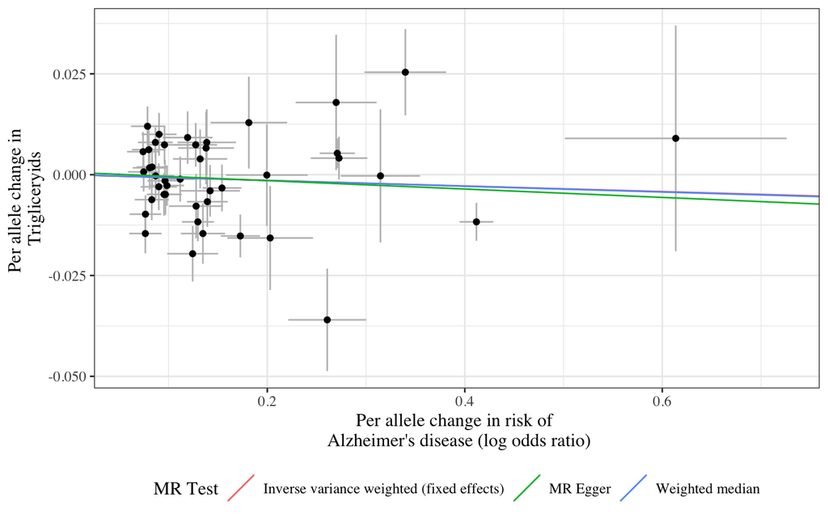

Fig. 1: Scatterplot of SNP effects for the association of Trait and LOAD

Figure 2 and Table 1 shows the SNP-specific effects and overall IVW, weighted median and Egger regression causal estimates of genetically predicted risk of LOAD on Trigliceryids.

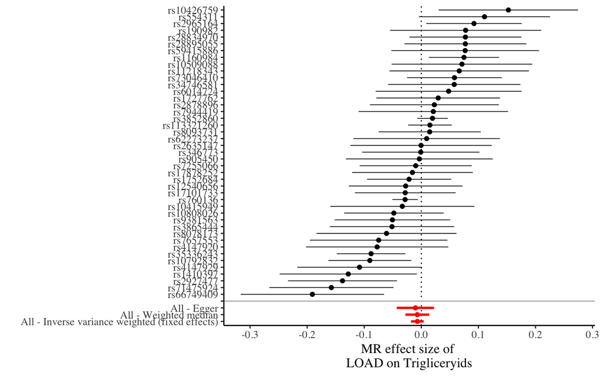

Fig. 2: Forrest plot of Wald ratios and 95% CIs for SNP-specific and overall IVW, Weighted median and Egger associations

**Table 1:** MR estimates for LOAD on Trigliceryids

|  | SNP | b | se | p |
| --- | --- | --- | --- | --- |
| 1 | rs10415949 | -0.0332963374 | 0.064372919 | 0.604987670 |
| 2 | rs10426759 | 0.1524777637 | 0.062261753 | 0.014326157 |
| 3 | rs10509088 | 0.0711527854 | 0.062879206 | 0.257811495 |
| 4 | rs10792832 | -0.0902081727 | 0.037008481 | 0.014789214 |
| 5 | rs10808026 | -0.0480976310 | 0.044508256 | 0.279854985 |
| 6 | rs11218343 | 0.0663700408 | 0.062291435 | 0.286660494 |
| 7 | rs113321260 | 0.0150403522 | 0.019442406 | 0.439176301 |
| 8 | rs1160984 | 0.0747498529 | 0.031489111 | 0.017604569 |
| 9 | rs12540656 | -0.0274390244 | 0.050813008 | 0.589197032 |
| 10 | rs1410397 | -0.1279373368 | 0.061357702 | 0.037059645 |

[output cut: 36 more lines]

Figure 3 shows a funnel plot to detect pleiotropy and Table 2 show the results of Cochrans Q heterogeneity test to assess for the presence of pleiotropy.

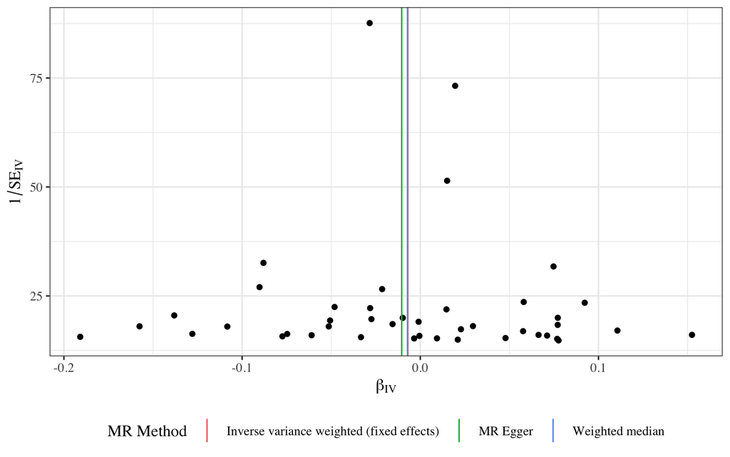

Fig. 3: Funnel plot of the Trait – LOAD causal estimates against their precession

**Table 2:** Heterogenity tests for Trigliceryids and LOAD

| exposure | outcome | method | Q | Q_df | Q_pval |
| --- | --- | --- | --- | --- | --- |
| LOAD | trig | MR Egger | 96.14783 | 41 | 2.528031e-06 |
| LOAD | trig | Inverse variance weighted | 96.28561 | 42 | 3.799739e-06 |

**Table 3:** Test for directional pleitropy for LOAD and Trigliceryids

| id.exposure | id.outcome | outcome | exposure | egger_intercept | se | pval |
| --- | --- | --- | --- | --- | --- | --- |
| 2YuQPj | MAZMrZ | trig | LOAD | 0.0006302524 | 0.002600116 | 0.8096834 |

### AAOS ~ Trigliceryids

Figure 4 illustrates the SNP-specific associations with AAOS versus the association between each SNP and Trigliceryids.

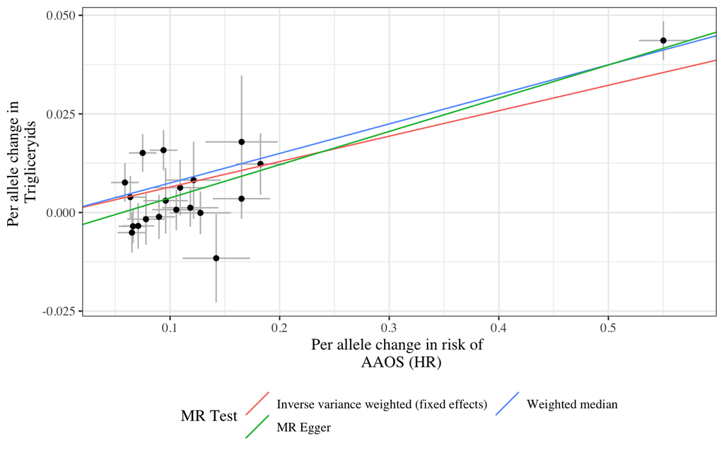

Fig. 4: Scatterplot of SNP effects for the association of Trait and AAOS

Figure 5 and Table 4 shows the SNP-specific effects and overall IVW, weighted median and Egger regression causal estimates of genetically predicted AAOS on Trigliceryids.

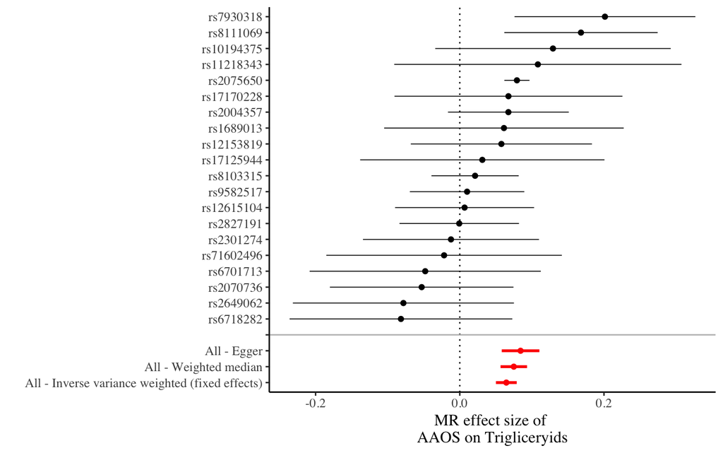

Fig. 5: Forrest plot of Wald ratios and 95% CIs for SNP-specific and overall IVW, Weighted median and Egger associations

**Table 4:** MR estimates for AAOS and Trigliceryids

|  | SNP | b | se | p |
| --- | --- | --- | --- | --- |
| 1 | rs10194375 | 0.1292517007 | 0.083333333 | 1.208968e-01 |
| 2 | rs11218343 | 0.1082879613 | 0.101633394 | 2.866605e-01 |
| 3 | rs12153819 | 0.0576923077 | 0.064102564 | 3.681203e-01 |
| 4 | rs12615104 | 0.0066225166 | 0.049195837 | 8.929160e-01 |
| 5 | rs1689013 | 0.0612244898 | 0.084772370 | 4.701579e-01 |
| 6 | rs17125944 | 0.0312500000 | 0.086458333 | 7.177662e-01 |
| 7 | rs17170228 | 0.0674897119 | 0.080658436 | 4.027417e-01 |
| 8 | rs2004357 | 0.0673972603 | 0.042739726 | 1.148132e-01 |
| 9 | rs2070736 | -0.0528700906 | 0.064954683 | 4.156716e-01 |
| 10 | rs2075650 | 0.0792439113 | 0.008905852 | 5.688293e-19 |

[output cut: 13 more lines]

Figure 6 shows a funnel plot to detect pleiotropy and Table 5 show the results of Cochrans Q heterogeneity test to assess for the presence of pleiotropy.

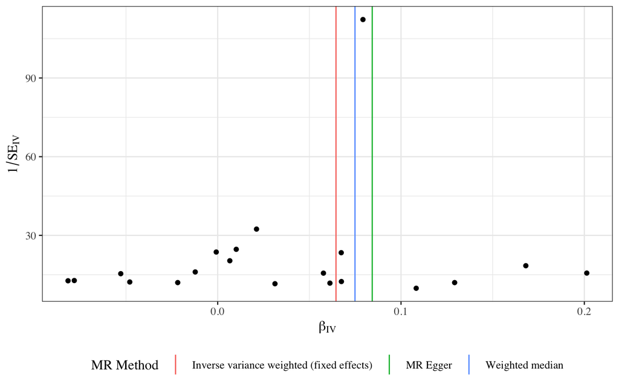

Fig. 6: Funnel plot of the traitohol Conumption – AAOS causal estimates against their precession

**Table 5:** Heterogenity tests for AAOS and Trigliceryids

| exposure | outcome | method | Q | Q_df | Q_pval |
| --- | --- | --- | --- | --- | --- |
| AAOS | trig | MR Egger | 27.58983 | 18 | 0.06857770 |
| AAOS | trig | Inverse variance weighted | 33.96215 | 19 | 0.01856745 |

**Table 6:** Test for directional pleitropy for AAOS and Trigliceryids

| id.exposure | id.outcome | outcome | exposure | egger_intercept | se | pval |
| --- | --- | --- | --- | --- | --- | --- |
| XFrAcs | dXoDO7 | trig | AAOS | -0.004739157 | 0.002324292 | 0.05641486 |

### HV ~ Trigliceryids

Figure 4 illustrates the SNP-specific associations with hipv versus the association between each SNP and Trigliceryids.

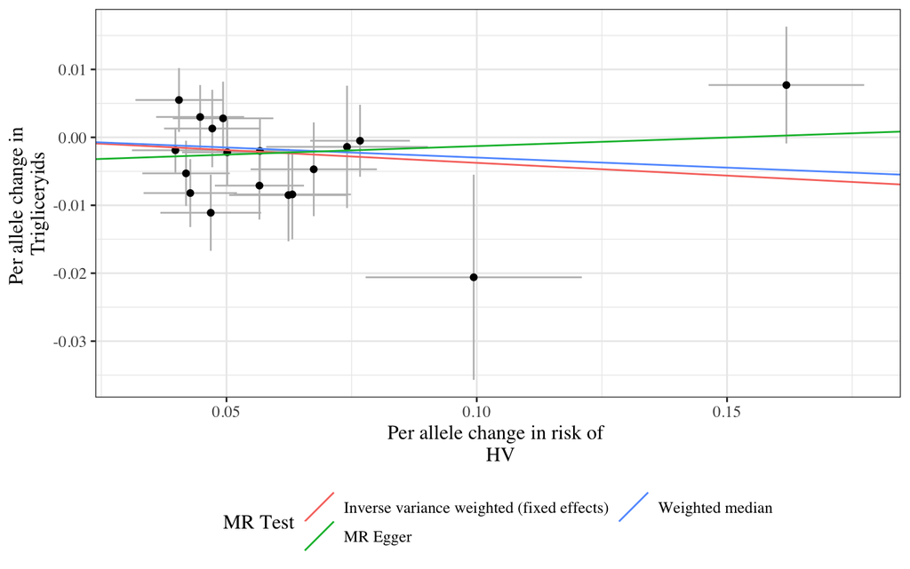

Fig. 4: Scatterplot of SNP effects for the association of Trait and hipv

Figure 5 and Table 4 shows the SNP-specific effects and overall IVW, weighted median and Egger regression causal estimates of genetically predicted HV on Trigliceryids.

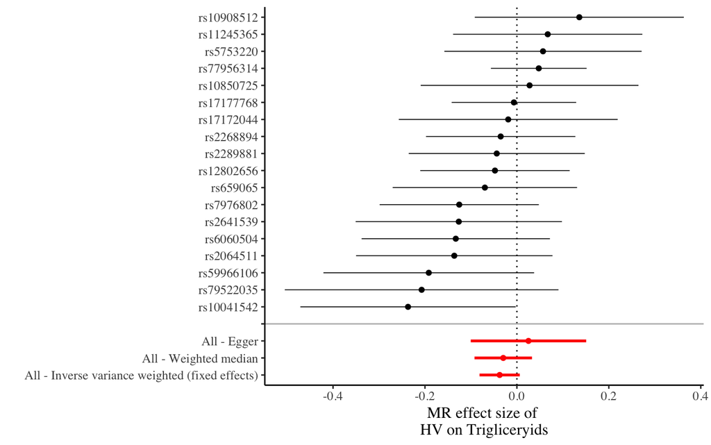

Fig. 5: Forrest plot of Wald ratios and 95% CIs for SNP-specific and overall IVW, Weighted median and Egger associations

**Table 4:** MR estimates for HV and Trigliceryids

|  | SNP | b | se | p |
| --- | --- | --- | --- | --- |
| 1 | rs10041542 | -0.236875917 | 0.11950497 | 0.04746325 |
| 2 | rs10850725 | 0.027564647 | 0.12086038 | 0.81959169 |
| 3 | rs10908512 | 0.135763279 | 0.11601589 | 0.24191536 |
| 4 | rs11245365 | 0.067052177 | 0.10504841 | 0.52327980 |
| 5 | rs12802656 | -0.047743719 | 0.08292330 | 0.56477905 |
| 6 | rs17172044 | -0.018897758 | 0.12148559 | 0.87638336 |
| 7 | rs17177768 | -0.006520398 | 0.06911622 | 0.92483938 |
| 8 | rs2064511 | -0.136257052 | 0.10900564 | 0.21129955 |
| 9 | rs2268894 | -0.035284757 | 0.08291918 | 0.67044896 |
| 10 | rs2289881 | -0.043871106 | 0.09771292 | 0.65344638 |

[output cut: 11 more lines]

Figure 6 shows a funnel plot to detect pleiotropy and Table 5 show the results of Cochrans Q heterogeneity test to assess for the presence of pleiotropy.

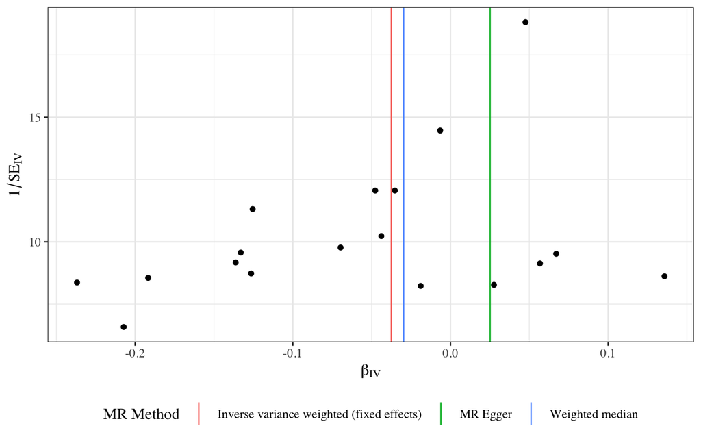

Fig. 6: Funnel plot of the traitohol Conumption – hipv causal estimates against their precession

**Table 5:** Heterogenity tests for HV and Trigliceryids

| exposure | outcome | method | Q | Q_df | Q_pval |
| --- | --- | --- | --- | --- | --- |
| HV | trig | MR Egger | 15.09223 | 16 | 0.5178938 |
| HV | trig | Inverse variance weighted | 16.18209 | 17 | 0.5109648 |

**Table 6:** Test for directional pleitropy for HV and Trigliceryids

| id.exposure | id.outcome | outcome | exposure | egger_intercept | se | pval |
| --- | --- | --- | --- | --- | --- | --- |
| 96crsN | WWtMn2 | trig | HV | -0.003801406 | 0.003641321 | 0.3120196 |

### AB42 ~ Trigliceryids

Figure 1 illustrates the SNP-specific associations with AB42 versus the association between each SNP and Trigliceryids.

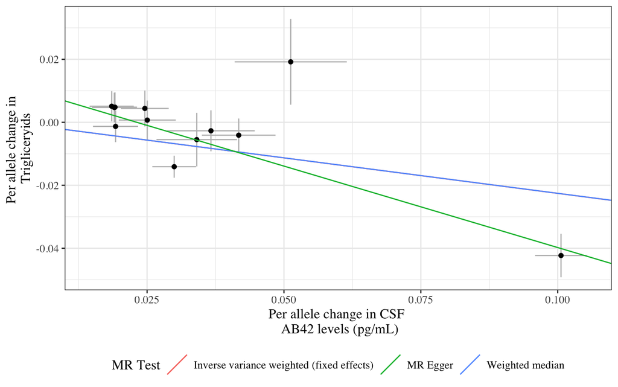

Fig. 1: Scatterplot of SNP effects for the association of trait and AB42

Figure 2 and Table 7 shows the SNP-specific effects and overall IVW, weighted median and Egger regression causal estimates of genetically predicted CSF AB42 levels and Trigliceryids.

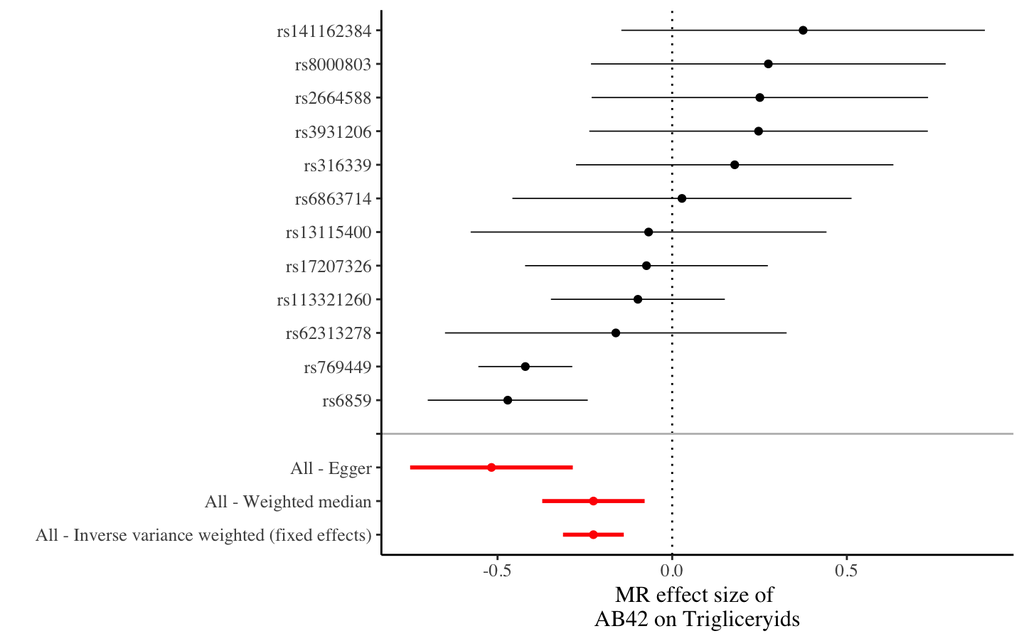

Fig. 2: Forrest plot of Wald ratios and 95% CIs for SNP-specific and overall IVW, Weighted median and Egger associations

**Table 7:** MR estimates for Trigliceryids and AB42

|  | SNP | b | se | p |
| --- | --- | --- | --- | --- |
| 1 | rs113321260 | -0.09825066 | 0.12700695 | 4.391763e-01 |
| 2 | rs13115400 | -0.06756757 | 0.25987526 | 7.948638e-01 |
| 3 | rs141162384 | 0.37478040 | 0.26546945 | 1.580193e-01 |
| 4 | rs17207326 | -0.07364975 | 0.17730496 | 6.778604e-01 |
| 5 | rs2664588 | 0.25091479 | 0.24568740 | 3.071234e-01 |
| 6 | rs316339 | 0.17893453 | 0.23180155 | 4.401560e-01 |
| 7 | rs3931206 | 0.24723830 | 0.24723830 | 3.173105e-01 |
| 8 | rs62313278 | -0.16143235 | 0.24948635 | 5.175939e-01 |
| 9 | rs6859 | -0.47078464 | 0.11686144 | 5.611681e-05 |
| 10 | rs6863714 | 0.02796644 | 0.24770276 | 9.101073e-01 |

[output cut: 5 more lines]

Figure 3 shows a funnel plot to detect pleiotropy and Table 8 show the results of Cochrans Q heterogeneity test to assess for the presence of pleiotropy.

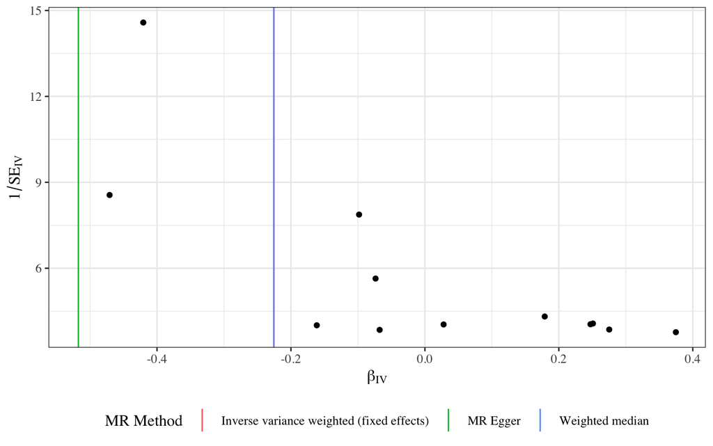

Fig. 3: Funnel plot of the trait – AB42 causal estimates against their precession

**Table 8:** Heterogenity tests for AB42 and Trigliceryids

| id.exposure | id.outcome | outcome | exposure | method | Q | Q_df | Q_pval |
| --- | --- | --- | --- | --- | --- | --- | --- |
| MzNyKB | lSrtLK | trig | AB42 | MR Egger | 19.19246 | 10 | 0.0378852129 |
| MzNyKB | lSrtLK | trig | AB42 | Inverse variance weighted | 35.01612 | 11 | 0.0002462892 |

**Table 9:** Test for directional pleitropy for AB42 and Trigliceryids

| id.exposure | id.outcome | outcome | exposure | egger_intercept | se | pval |
| --- | --- | --- | --- | --- | --- | --- |
| MzNyKB | lSrtLK | trig | AB42 | 0.01197175 | 0.004169361 | 0.01662983 |

### Ptau ~ Trigliceryids

Figure 1 illustrates the SNP-specific associations with Ptau versus the association between each SNP and Trigliceryids.

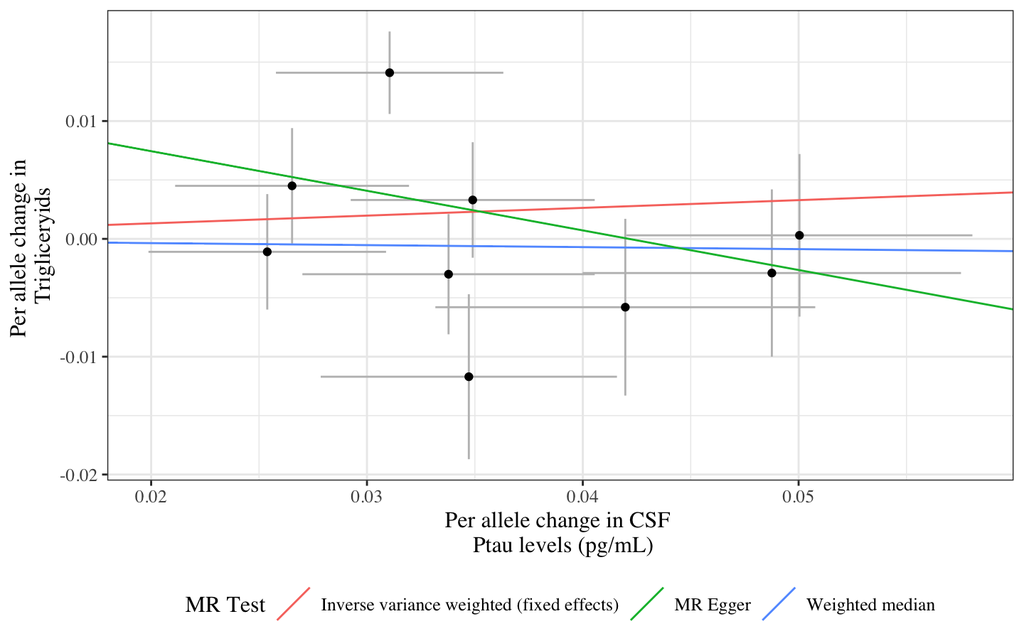

Fig. 1: Scatterplot of SNP effects for the association of trait and Ptau

Figure 2 and Table 9 shows the SNP-specific effects and overall IVW, weighted median and Egger regression causal estimates of genetically predicted Ptau on Trigliceryids.

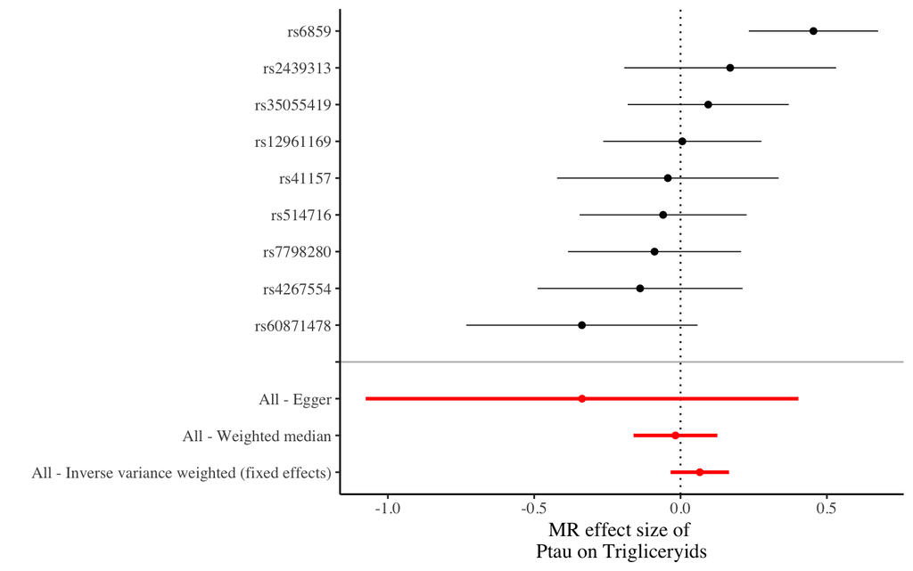

Fig. 2: Forrest plot of Wald ratios and 95% CIs for SNP-specific and overall IVW, Weighted median and Egger associations

**Table 9:** MR estimates for Ptau and Trigliceryids

|  | SNP | b | se | p |
| --- | --- | --- | --- | --- |
| 1 | rs12961169 | 0.005995204 | 0.13788969 | 9.653203e-01 |
| 2 | rs2439313 | 0.169619299 | 0.18469657 | 3.584266e-01 |
| 3 | rs35055419 | 0.094555874 | 0.14040115 | 5.006487e-01 |
| 4 | rs41157 | -0.043341214 | 0.19306541 | 8.223762e-01 |
| 5 | rs4267554 | -0.138193948 | 0.17869907 | 4.393251e-01 |
| 6 | rs514716 | -0.059474979 | 0.14561116 | 6.829428e-01 |
| 7 | rs60871478 | -0.336981567 | 0.20161290 | 9.463706e-02 |
| 8 | rs6859 | 0.454106280 | 0.11272142 | 5.611681e-05 |
| 9 | rs7798280 | -0.088809947 | 0.15097691 | 5.563744e-01 |
| 10 | All - Inverse variance weighted (fixed effects) | 0.065801937 | 0.05095677 | 1.965897e-01 |

[output cut: 2 more lines]

Figure 3 shows a funnel plot to detect pleiotropy and Table 10 show the results of Cochrans Q heterogeneity test to assess for the presence of pleiotropy.

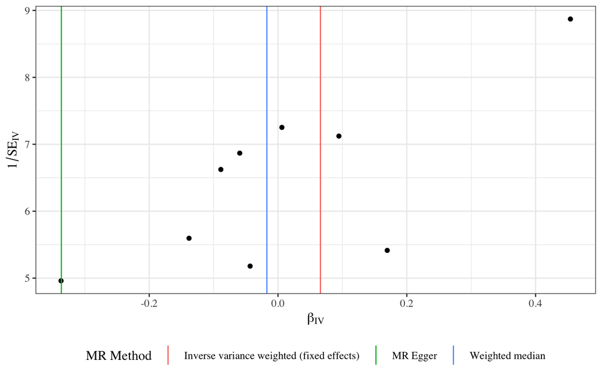

Fig. 3: Funnel plot of the trait – Ptau causal estimates against their precession

**Table 10:** Heterogenity tests for Ptau and Trigliceryids

| id.exposure | id.outcome | outcome | exposure | method | Q | Q_df | Q_pval |
| --- | --- | --- | --- | --- | --- | --- | --- |
| qlPDVi | k5pYCf | trig | Ptau | MR Egger | 16.93722 | 7 | 0.01780553 |
| qlPDVi | k5pYCf | trig | Ptau | Inverse variance weighted | 19.81567 | 8 | 0.01105637 |

**Table 11:** Test for directional pleitropy for Ptau and Trigliceryids

| id.exposure | id.outcome | outcome | exposure | egger_intercept | se | pval |
| --- | --- | --- | --- | --- | --- | --- |
| qlPDVi | k5pYCf | trig | Ptau | 0.01418468 | 0.01300504 | 0.3115169 |

### Tau ~ Trigliceryids

Figure 1 illustrates the SNP-specific associations with CSF Tau levels versus the association between each SNP and Trigliceryids.

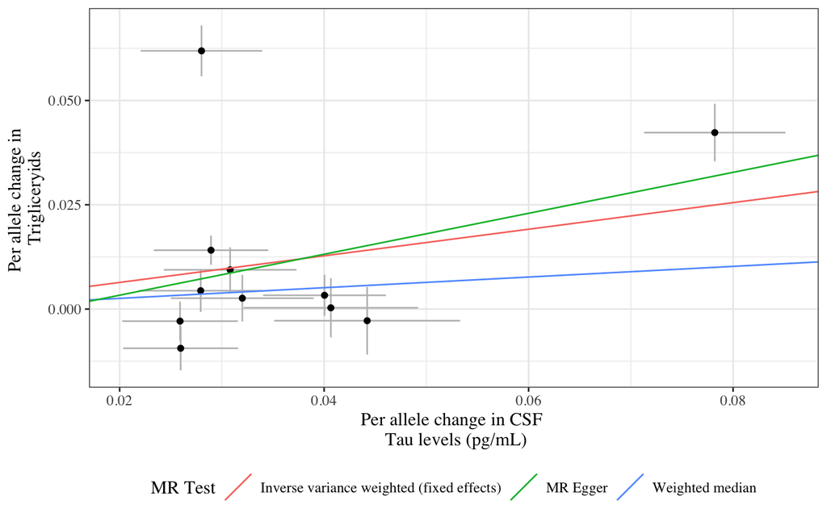

Fig. 1: Scatterplot of SNP effects for the association of trait and Tau

Figure 2 and Table 12 shows the SNP-specific effects and overall IVW, weighted median and Egger regression causal estimates of genetically predicted Tau on Trigliceryids.

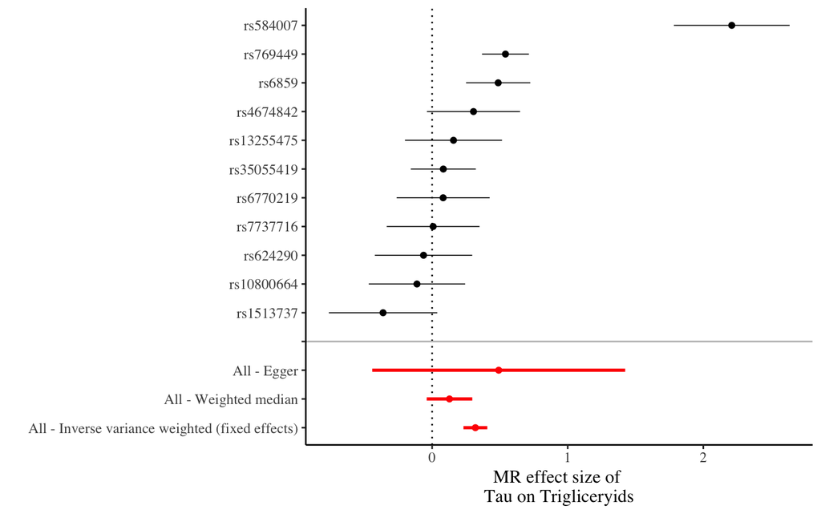

Fig. 2: Forrest plot of Wald ratios and 95% CIs for SNP-specific and overall IVW, Weighted median and Egger associations

**Table 12:** MR estimates for Tau and Trigliceryids

|  | SNP | b | se | p |
| --- | --- | --- | --- | --- |
| 1 | rs10800664 | -0.111925897 | 0.18139714 | 5.372207e-01 |
| 2 | rs13255475 | 0.157536699 | 0.18259936 | 3.882776e-01 |
| 3 | rs1513737 | -0.361956103 | 0.20408163 | 7.613184e-02 |
| 4 | rs35055419 | 0.082417582 | 0.12237762 | 5.006487e-01 |
| 5 | rs4674842 | 0.305095748 | 0.17526777 | 8.172903e-02 |
| 6 | rs584007 | 2.209925027 | 0.21777936 | 3.398178e-24 |
| 7 | rs624290 | -0.063334087 | 0.18321647 | 7.295840e-01 |
| 8 | rs6770219 | 0.081250000 | 0.17500000 | 6.424431e-01 |
| 9 | rs6859 | 0.487214927 | 0.12093988 | 5.611681e-05 |
| 10 | rs769449 | 0.540851554 | 0.08822401 | 8.763924e-10 |

[output cut: 4 more lines]

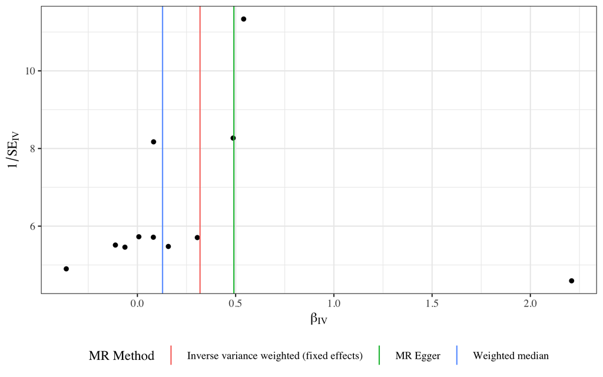

Fig. 3: Funnel plot of the trait – Tau causal estimates against their precession

**Table 14:** Heterogenity tests for Tau and Trigliceryids

| id.exposure | id.outcome | outcome | exposure | method | Q | Q_df | Q_pval |
| --- | --- | --- | --- | --- | --- | --- | --- |
| 2SjZb0 | ytGlWS | trig | Tau | MR Egger | 112.4954 | 9 | 4.560745e-20 |
| 2SjZb0 | ytGlWS | trig | Tau | Inverse variance weighted | 114.3358 | 10 | 7.105634e-20 |

**Table 15:** Test for directional pleitropy for Tau and Trigliceryids

| id.exposure | id.outcome | outcome | exposure | egger_intercept | se | pval |
| --- | --- | --- | --- | --- | --- | --- |
| 2SjZb0 | ytGlWS | trig | Tau | -0.006504462 | 0.01695109 | 0.7100941 |

## MR analysis results

| exposure | outcome | method | nsnp | b | se | pval | Signif |
| --- | --- | --- | --- | --- | --- | --- | --- |
| LOAD | trig | IVW | 43 | -0.006981663 | 0.005690018 | 2.198218e-01 |  |
| LOAD | trig | Weighted median | 43 | -0.007164455 | 0.010466269 | 4.936418e-01 |  |
| LOAD | trig | MR Egger | 43 | -0.010435009 | 0.016700210 | 5.355363e-01 |  |
| AAOS | trig | IVW | 20 | 0.064546401 | 0.007373319 | 2.058295e-18 | *** |
| AAOS | trig | Weighted median | 20 | 0.074894875 | 0.009550845 | 4.444828e-15 | *** |
| AAOS | trig | MR Egger | 20 | 0.084311608 | 0.013315352 | 5.752207e-06 | *** |
| HV | trig | IVW | 18 | -0.037535990 | 0.022328442 | 9.274657e-02 | . |
| HV | trig | Weighted median | 18 | -0.029695498 | 0.032820393 | 3.655777e-01 |  |
| HV | trig | MR Egger | 18 | 0.025163887 | 0.064075719 | 6.997081e-01 |  |
| AB42 | trig | IVW | 12 | -0.225609907 | 0.044394216 | 3.735479e-07 | *** |

[output cut: 8 more lines]